# Risk Factor Analysis

## Outcome Variable

**Outcome Variable:** y_rate_len

## Predictor Variables

**Intervention Variable:** trth2o

**Adjustment Set:**

- arm
- sex
- W_mage
- meducyrs
- feducyrs
- hfoodsec
- W_mhtcm
- W_mwtkg
- W_mbmi
- W_nrooms
- W_nhh
- W_nchldlt5
- cleanck
- impfloor
- impsan
- safeh20
- delta_meducyrs
- delta_feducyrs
- delta_hfoodsec
- delta_W_mhtcm
- delta_W_mwtkg
- delta_W_mbmi
- delta_W_nrooms
- delta_W_nhh
- delta_W_nchldlt5
- delta_cleanck
- delta_impfloor
- delta_impsan
- delta_safeh20

## Stratifying Variables

The analysis was stratified on these variable(s):

- agecat
- studyid
- country

## Data Summary

| agecat | studyid | country | trth2o | n_cell | n |
| --- | --- | --- | --- | --- | --- |
| 0-3 months | ki0047075b-MAL-ED | BANGLADESH | 0 | 2 | 134 |
| 0-3 months | ki0047075b-MAL-ED | BANGLADESH | 1 | 132 | 134 |
| 0-3 months | ki1017093b-PROVIDE | BANGLADESH | 0 | 620 | 634 |
| 0-3 months | ki1017093b-PROVIDE | BANGLADESH | 1 | 14 | 634 |
| 0-3 months | ki1017093c-NIH-Crypto | BANGLADESH | 0 | 319 | 720 |
| 0-3 months | ki1017093c-NIH-Crypto | BANGLADESH | 1 | 401 | 720 |
| 0-3 months | ki0047075b-MAL-ED | BRAZIL | 0 | 72 | 84 |
| 0-3 months | ki0047075b-MAL-ED | BRAZIL | 1 | 12 | 84 |
| 0-3 months | ki0047075b-MAL-ED | INDIA | 0 | 4 | 6 |
| 0-3 months | ki0047075b-MAL-ED | INDIA | 1 | 2 | 6 |
| 0-3 months | ki1000108-CMC-V-BCS-2002 | INDIA | 1 | 25 | 25 |
| 0-3 months | ki1000108-IRC | INDIA | 1 | 118 | 118 |
| 0-3 months | ki0047075b-MAL-ED | NEPAL | 0 | 12 | 63 |
| 0-3 months | ki0047075b-MAL-ED | NEPAL | 1 | 51 | 63 |
| 0-3 months | ki0047075b-MAL-ED | PERU | 0 | 9 | 46 |
| 0-3 months | ki0047075b-MAL-ED | PERU | 1 | 37 | 46 |
| 0-3 months | ki0047075b-MAL-ED | SOUTH AFRICA | 0 | 9 | 10 |
| 0-3 months | ki0047075b-MAL-ED | SOUTH AFRICA | 1 | 1 | 10 |
| 0-3 months | ki0047075b-MAL-ED | TANZANIA, UNITED REPUBLIC OF | 0 | 32 | 38 |
| 0-3 months | ki0047075b-MAL-ED | TANZANIA, UNITED REPUBLIC OF | 1 | 6 | 38 |
| 3-6 months | ki0047075b-MAL-ED | BANGLADESH | 0 | 2 | 132 |
| 3-6 months | ki0047075b-MAL-ED | BANGLADESH | 1 | 130 | 132 |
| 3-6 months | ki1017093b-PROVIDE | BANGLADESH | 0 | 561 | 574 |
| 3-6 months | ki1017093b-PROVIDE | BANGLADESH | 1 | 13 | 574 |
| 3-6 months | ki1017093c-NIH-Crypto | BANGLADESH | 0 | 313 | 695 |
| 3-6 months | ki1017093c-NIH-Crypto | BANGLADESH | 1 | 382 | 695 |
| 3-6 months | ki0047075b-MAL-ED | BRAZIL | 0 | 90 | 103 |
| 3-6 months | ki0047075b-MAL-ED | BRAZIL | 1 | 13 | 103 |
| 3-6 months | ki0047075b-MAL-ED | INDIA | 0 | 4 | 7 |
| 3-6 months | ki0047075b-MAL-ED | INDIA | 1 | 3 | 7 |

[output cut: 56 more lines]

The following strata were considered:

- agecat: 0-3 months, studyid: ki0047075b-MAL-ED, country: BANGLADESH
- agecat: 0-3 months, studyid: ki0047075b-MAL-ED, country: BRAZIL
- agecat: 0-3 months, studyid: ki0047075b-MAL-ED, country: INDIA
- agecat: 0-3 months, studyid: ki0047075b-MAL-ED, country: NEPAL
- agecat: 0-3 months, studyid: ki0047075b-MAL-ED, country: PERU
- agecat: 0-3 months, studyid: ki0047075b-MAL-ED, country: SOUTH AFRICA
- agecat: 0-3 months, studyid: ki0047075b-MAL-ED, country: TANZANIA, UNITED REPUBLIC OF
- agecat: 0-3 months, studyid: ki1000108-CMC-V-BCS-2002, country: INDIA
- agecat: 0-3 months, studyid: ki1000108-IRC, country: INDIA
- agecat: 0-3 months, studyid: ki1017093b-PROVIDE, country: BANGLADESH
- agecat: 0-3 months, studyid: ki1017093c-NIH-Crypto, country: BANGLADESH
- agecat: 12-24 months, studyid: ki0047075b-MAL-ED, country: BANGLADESH
- agecat: 12-24 months, studyid: ki0047075b-MAL-ED, country: BRAZIL
- agecat: 12-24 months, studyid: ki0047075b-MAL-ED, country: INDIA
- agecat: 12-24 months, studyid: ki0047075b-MAL-ED, country: NEPAL
- agecat: 12-24 months, studyid: ki0047075b-MAL-ED, country: PERU
- agecat: 12-24 months, studyid: ki0047075b-MAL-ED, country: SOUTH AFRICA
- agecat: 12-24 months, studyid: ki0047075b-MAL-ED, country: TANZANIA, UNITED REPUBLIC OF
- agecat: 12-24 months, studyid: ki1000108-CMC-V-BCS-2002, country: INDIA
- agecat: 12-24 months, studyid: ki1000108-IRC, country: INDIA
- agecat: 12-24 months, studyid: ki1017093b-PROVIDE, country: BANGLADESH
- agecat: 12-24 months, studyid: ki1017093c-NIH-Crypto, country: BANGLADESH
- agecat: 12-24 months, studyid: ki1113344-GMS-Nepal, country: NEPAL
- agecat: 3-6 months, studyid: ki0047075b-MAL-ED, country: BANGLADESH
- agecat: 3-6 months, studyid: ki0047075b-MAL-ED, country: BRAZIL
- agecat: 3-6 months, studyid: ki0047075b-MAL-ED, country: INDIA
- agecat: 3-6 months, studyid: ki0047075b-MAL-ED, country: NEPAL
- agecat: 3-6 months, studyid: ki0047075b-MAL-ED, country: PERU
- agecat: 3-6 months, studyid: ki0047075b-MAL-ED, country: SOUTH AFRICA
- agecat: 3-6 months, studyid: ki0047075b-MAL-ED, country: TANZANIA, UNITED REPUBLIC OF
- agecat: 3-6 months, studyid: ki1000108-CMC-V-BCS-2002, country: INDIA
- agecat: 3-6 months, studyid: ki1000108-IRC, country: INDIA
- agecat: 3-6 months, studyid: ki1017093b-PROVIDE, country: BANGLADESH
- agecat: 3-6 months, studyid: ki1017093c-NIH-Crypto, country: BANGLADESH
- agecat: 3-6 months, studyid: ki1113344-GMS-Nepal, country: NEPAL
- agecat: 6-12 months, studyid: ki0047075b-MAL-ED, country: BANGLADESH
- agecat: 6-12 months, studyid: ki0047075b-MAL-ED, country: BRAZIL
- agecat: 6-12 months, studyid: ki0047075b-MAL-ED, country: INDIA
- agecat: 6-12 months, studyid: ki0047075b-MAL-ED, country: NEPAL
- agecat: 6-12 months, studyid: ki0047075b-MAL-ED, country: PERU
- agecat: 6-12 months, studyid: ki0047075b-MAL-ED, country: SOUTH AFRICA
- agecat: 6-12 months, studyid: ki0047075b-MAL-ED, country: TANZANIA, UNITED REPUBLIC OF
- agecat: 6-12 months, studyid: ki1000108-CMC-V-BCS-2002, country: INDIA
- agecat: 6-12 months, studyid: ki1000108-IRC, country: INDIA
- agecat: 6-12 months, studyid: ki1017093b-PROVIDE, country: BANGLADESH
- agecat: 6-12 months, studyid: ki1017093c-NIH-Crypto, country: BANGLADESH
- agecat: 6-12 months, studyid: ki1113344-GMS-Nepal, country: NEPAL

### Dropped Strata

Some strata were dropped due to rare outcomes:

- agecat: 0-3 months, studyid: ki0047075b-MAL-ED, country: BANGLADESH
- agecat: 0-3 months, studyid: ki0047075b-MAL-ED, country: INDIA
- agecat: 0-3 months, studyid: ki0047075b-MAL-ED, country: SOUTH AFRICA
- agecat: 3-6 months, studyid: ki0047075b-MAL-ED, country: BANGLADESH
- agecat: 3-6 months, studyid: ki0047075b-MAL-ED, country: INDIA
- agecat: 3-6 months, studyid: ki1113344-GMS-Nepal, country: NEPAL
- agecat: 3-6 months, studyid: ki0047075b-MAL-ED, country: SOUTH AFRICA
- agecat: 6-12 months, studyid: ki0047075b-MAL-ED, country: BANGLADESH
- agecat: 6-12 months, studyid: ki0047075b-MAL-ED, country: INDIA
- agecat: 6-12 months, studyid: ki1113344-GMS-Nepal, country: NEPAL
- agecat: 6-12 months, studyid: ki0047075b-MAL-ED, country: SOUTH AFRICA
- agecat: 12-24 months, studyid: ki0047075b-MAL-ED, country: BANGLADESH
- agecat: 12-24 months, studyid: ki0047075b-MAL-ED, country: INDIA
- agecat: 12-24 months, studyid: ki1113344-GMS-Nepal, country: NEPAL
- agecat: 12-24 months, studyid: ki0047075b-MAL-ED, country: SOUTH AFRICA

## Methods Detail

We’re interested in the causal parameters $E[Y_a]$ for all values of $a \in \mathcal{A}$. These parameters represent the mean outcome if, possibly contrary to fact, we intervened to set all units to have $A=a$. Under the randomization and positivity assumptions, these are identified by the statistical parameters $\psi_a=E_W[E_{Y|A,W}(Y|A=a,W)]$. In addition, we’re interested in the mean of $Y$, $E[Y]$ under no intervention (the observed mean). We will estimate these parameters by using SuperLearner to fit the relevant likelihood factors – $E_{Y|A,W}(Y|A=a,W)$ and $p(A=a|W)$, and then updating our likelihood fit using a joint TMLE.

For unadjusted analyses ($W=\{\}$), initial likelihoods were estimated using Lrnr_glm to estimate the simple $E(Y|A)$ and Lrnr_mean to estimate $p(A)$. For adjusted analyses, a small library containing Lrnr_glmnet, Lrnr_xgboost, and Lrnr_mean was used.

[output not shown]

[output cut: 801 more lines]

[output not shown]

# Results Detail

## Results Plots

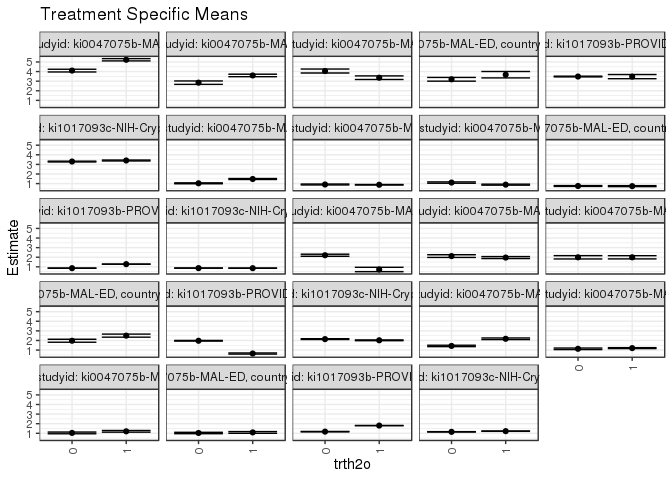

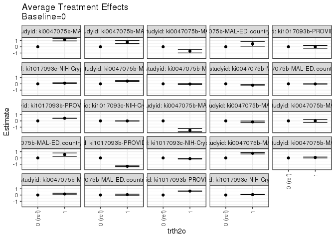

## Results Table

### Parameter: TSM

| agecat | studyid | country | intervention_level | baseline_level | estimate | ci_lower | ci_upper |
| --- | --- | --- | --- | --- | --- | --- | --- |
| 0-3 months | ki0047075b-MAL-ED | BRAZIL | 0 | NA | 4.1014327 | 3.9584909 | 4.2443745 |
| 0-3 months | ki0047075b-MAL-ED | BRAZIL | 1 | NA | 5.2302740 | 5.1123810 | 5.3481669 |
| 0-3 months | ki0047075b-MAL-ED | NEPAL | 0 | NA | 2.8441621 | 2.6653378 | 3.0229864 |
| 0-3 months | ki0047075b-MAL-ED | NEPAL | 1 | NA | 3.5958839 | 3.4650995 | 3.7266682 |
| 0-3 months | ki0047075b-MAL-ED | PERU | 0 | NA | 4.0585993 | 3.8513682 | 4.2658304 |
| 0-3 months | ki0047075b-MAL-ED | PERU | 1 | NA | 3.3600867 | 3.1735009 | 3.5466725 |
| 0-3 months | ki0047075b-MAL-ED | TANZANIA, UNITED REPUBLIC OF | 0 | NA | 3.1953217 | 3.0020678 | 3.3885756 |
| 0-3 months | ki0047075b-MAL-ED | TANZANIA, UNITED REPUBLIC OF | 1 | NA | 3.6745316 | 3.3407110 | 4.0083522 |
| 0-3 months | ki1017093b-PROVIDE | BANGLADESH | 0 | NA | 3.4828603 | 3.4430972 | 3.5226233 |
| 0-3 months | ki1017093b-PROVIDE | BANGLADESH | 1 | NA | 3.4742712 | 3.2558918 | 3.6926505 |
| 0-3 months | ki1017093c-NIH-Crypto | BANGLADESH | 0 | NA | 3.2987095 | 3.2578890 | 3.3395300 |
| 0-3 months | ki1017093c-NIH-Crypto | BANGLADESH | 1 | NA | 3.4080079 | 3.3617203 | 3.4542955 |
| 3-6 months | ki0047075b-MAL-ED | BRAZIL | 0 | NA | 2.2076548 | 2.1000183 | 2.3152912 |
| 3-6 months | ki0047075b-MAL-ED | BRAZIL | 1 | NA | 0.7236561 | 0.4959257 | 0.9513864 |
| 3-6 months | ki0047075b-MAL-ED | NEPAL | 0 | NA | 2.1197806 | 1.9785064 | 2.2610549 |
| 3-6 months | ki0047075b-MAL-ED | NEPAL | 1 | NA | 1.9650331 | 1.8628726 | 2.0671936 |
| 3-6 months | ki0047075b-MAL-ED | PERU | 0 | NA | 1.9915745 | 1.8202223 | 2.1629266 |
| 3-6 months | ki0047075b-MAL-ED | PERU | 1 | NA | 1.9941935 | 1.8277033 | 2.1606838 |
| 3-6 months | ki0047075b-MAL-ED | TANZANIA, UNITED REPUBLIC OF | 0 | NA | 1.9703687 | 1.8160351 | 2.1247024 |
| 3-6 months | ki0047075b-MAL-ED | TANZANIA, UNITED REPUBLIC OF | 1 | NA | 2.5016704 | 2.3418286 | 2.6615123 |
| 3-6 months | ki1017093b-PROVIDE | BANGLADESH | 0 | NA | 1.9685935 | 1.9332005 | 2.0039864 |
| 3-6 months | ki1017093b-PROVIDE | BANGLADESH | 1 | NA | 0.6386626 | 0.5797224 | 0.6976027 |
| 3-6 months | ki1017093c-NIH-Crypto | BANGLADESH | 0 | NA | 2.1408743 | 2.0991246 | 2.1826240 |
| 3-6 months | ki1017093c-NIH-Crypto | BANGLADESH | 1 | NA | 2.0200097 | 1.9801489 | 2.0598706 |
| 6-12 months | ki0047075b-MAL-ED | BRAZIL | 0 | NA | 1.4314021 | 1.3606856 | 1.5021186 |
| 6-12 months | ki0047075b-MAL-ED | BRAZIL | 1 | NA | 2.1754919 | 2.0922711 | 2.2587127 |
| 6-12 months | ki0047075b-MAL-ED | NEPAL | 0 | NA | 1.1327024 | 1.0558174 | 1.2095874 |
| 6-12 months | ki0047075b-MAL-ED | NEPAL | 1 | NA | 1.2028097 | 1.1564868 | 1.2491327 |
| 6-12 months | ki0047075b-MAL-ED | PERU | 0 | NA | 1.0400373 | 0.9517888 | 1.1282858 |
| 6-12 months | ki0047075b-MAL-ED | PERU | 1 | NA | 1.2045029 | 1.1189467 | 1.2900590 |
| 6-12 months | ki0047075b-MAL-ED | TANZANIA, UNITED REPUBLIC OF | 0 | NA | 1.0339646 | 0.9628642 | 1.1050649 |
| 6-12 months | ki0047075b-MAL-ED | TANZANIA, UNITED REPUBLIC OF | 1 | NA | 1.0923814 | 1.0036693 | 1.1810935 |
| 6-12 months | ki1017093b-PROVIDE | BANGLADESH | 0 | NA | 1.1743103 | 1.1568747 | 1.1917458 |
| 6-12 months | ki1017093b-PROVIDE | BANGLADESH | 1 | NA | 1.8052016 | 1.7910014 | 1.8194019 |
| 6-12 months | ki1017093c-NIH-Crypto | BANGLADESH | 0 | NA | 1.1515929 | 1.1318237 | 1.1713622 |
| 6-12 months | ki1017093c-NIH-Crypto | BANGLADESH | 1 | NA | 1.2223791 | 1.2012970 | 1.2434612 |
| 12-24 months | ki0047075b-MAL-ED | BRAZIL | 0 | NA | 1.0321686 | 0.9873568 | 1.0769805 |
| 12-24 months | ki0047075b-MAL-ED | BRAZIL | 1 | NA | 1.4773101 | 1.4253496 | 1.5292706 |
| 12-24 months | ki0047075b-MAL-ED | NEPAL | 0 | NA | 0.9076558 | 0.8607696 | 0.9545421 |
| 12-24 months | ki0047075b-MAL-ED | NEPAL | 1 | NA | 0.8795024 | 0.8518125 | 0.9071924 |
| 12-24 months | ki0047075b-MAL-ED | PERU | 0 | NA | 1.1090768 | 1.0422691 | 1.1758845 |
| 12-24 months | ki0047075b-MAL-ED | PERU | 1 | NA | 0.8916221 | 0.8407746 | 0.9424696 |
| 12-24 months | ki0047075b-MAL-ED | TANZANIA, UNITED REPUBLIC OF | 0 | NA | 0.7502791 | 0.7048604 | 0.7956979 |
| 12-24 months | ki0047075b-MAL-ED | TANZANIA, UNITED REPUBLIC OF | 1 | NA | 0.7350426 | 0.6832068 | 0.7868783 |
| 12-24 months | ki1017093b-PROVIDE | BANGLADESH | 0 | NA | 0.8603405 | 0.8481442 | 0.8725369 |
| 12-24 months | ki1017093b-PROVIDE | BANGLADESH | 1 | NA | 1.2795968 | 1.2730007 | 1.2861930 |
| 12-24 months | ki1017093c-NIH-Crypto | BANGLADESH | 0 | NA | 0.8660618 | 0.8522089 | 0.8799146 |
| 12-24 months | ki1017093c-NIH-Crypto | BANGLADESH | 1 | NA | 0.8605212 | 0.8461549 | 0.8748876 |

### Parameter: E(Y)

| agecat | studyid | country | intervention_level | baseline_level | estimate | ci_lower | ci_upper |
| --- | --- | --- | --- | --- | --- | --- | --- |
| 0-3 months | ki0047075b-MAL-ED | BRAZIL | NA | NA | 4.0715516 | 3.9418270 | 4.2012761 |
| 0-3 months | ki0047075b-MAL-ED | NEPAL | NA | NA | 3.6902242 | 3.5713067 | 3.8091418 |
| 0-3 months | ki0047075b-MAL-ED | PERU | NA | NA | 3.3427634 | 3.1861528 | 3.4993739 |
| 0-3 months | ki0047075b-MAL-ED | TANZANIA, UNITED REPUBLIC OF | NA | NA | 3.2714929 | 3.0881028 | 3.4548830 |
| 0-3 months | ki1017093b-PROVIDE | BANGLADESH | NA | NA | 3.4826706 | 3.4434873 | 3.5218539 |
| 0-3 months | ki1017093c-NIH-Crypto | BANGLADESH | NA | NA | 3.3028656 | 3.2646714 | 3.3410598 |
| 3-6 months | ki0047075b-MAL-ED | BRAZIL | NA | NA | 2.2227563 | 2.1133297 | 2.3321829 |
| 3-6 months | ki0047075b-MAL-ED | NEPAL | NA | NA | 1.9950101 | 1.8904604 | 2.0995599 |
| 3-6 months | ki0047075b-MAL-ED | PERU | NA | NA | 1.9903923 | 1.8466790 | 2.1341055 |
| 3-6 months | ki0047075b-MAL-ED | TANZANIA, UNITED REPUBLIC OF | NA | NA | 1.8159811 | 1.6776334 | 1.9543288 |
| 3-6 months | ki1017093b-PROVIDE | BANGLADESH | NA | NA | 1.9654454 | 1.9303798 | 2.0005110 |
| 3-6 months | ki1017093c-NIH-Crypto | BANGLADESH | NA | NA | 2.0057973 | 1.9693775 | 2.0422170 |
| 6-12 months | ki0047075b-MAL-ED | BRAZIL | NA | NA | 1.4128372 | 1.3473294 | 1.4783450 |
| 6-12 months | ki0047075b-MAL-ED | NEPAL | NA | NA | 1.1905799 | 1.1461403 | 1.2350196 |
| 6-12 months | ki0047075b-MAL-ED | PERU | NA | NA | 1.1709466 | 1.0976676 | 1.2442255 |
| 6-12 months | ki0047075b-MAL-ED | TANZANIA, UNITED REPUBLIC OF | NA | NA | 1.0440833 | 0.9736537 | 1.1145130 |
| 6-12 months | ki1017093b-PROVIDE | BANGLADESH | NA | NA | 1.1731762 | 1.1558671 | 1.1904853 |
| 6-12 months | ki1017093c-NIH-Crypto | BANGLADESH | NA | NA | 1.2281313 | 1.2106849 | 1.2455776 |
| 12-24 months | ki0047075b-MAL-ED | BRAZIL | NA | NA | 0.9771443 | 0.9389322 | 1.0153564 |
| 12-24 months | ki0047075b-MAL-ED | NEPAL | NA | NA | 0.8842512 | 0.8598045 | 0.9086979 |
| 12-24 months | ki0047075b-MAL-ED | PERU | NA | NA | 0.8452899 | 0.8040289 | 0.8865508 |
| 12-24 months | ki0047075b-MAL-ED | TANZANIA, UNITED REPUBLIC OF | NA | NA | 0.7446935 | 0.6968915 | 0.7924955 |
| 12-24 months | ki1017093b-PROVIDE | BANGLADESH | NA | NA | 0.8575519 | 0.8455586 | 0.8695452 |
| 12-24 months | ki1017093c-NIH-Crypto | BANGLADESH | NA | NA | 0.8755729 | 0.8637860 | 0.8873598 |

### Parameter: ATE

| agecat | studyid | country | intervention_level | baseline_level | estimate | ci_lower | ci_upper |
| --- | --- | --- | --- | --- | --- | --- | --- |
| 0-3 months | ki0047075b-MAL-ED | BRAZIL | 0 | 0 | 0.0000000 | 0.0000000 | 0.0000000 |
| 0-3 months | ki0047075b-MAL-ED | BRAZIL | 1 | 0 | 1.1288412 | 0.9289511 | 1.3287314 |
| 0-3 months | ki0047075b-MAL-ED | NEPAL | 0 | 0 | 0.0000000 | 0.0000000 | 0.0000000 |
| 0-3 months | ki0047075b-MAL-ED | NEPAL | 1 | 0 | 0.7517218 | 0.5107205 | 0.9927230 |
| 0-3 months | ki0047075b-MAL-ED | PERU | 0 | 0 | 0.0000000 | 0.0000000 | 0.0000000 |
| 0-3 months | ki0047075b-MAL-ED | PERU | 1 | 0 | -0.6985126 | -0.9871110 | -0.4099141 |
| 0-3 months | ki0047075b-MAL-ED | TANZANIA, UNITED REPUBLIC OF | 0 | 0 | 0.0000000 | 0.0000000 | 0.0000000 |
| 0-3 months | ki0047075b-MAL-ED | TANZANIA, UNITED REPUBLIC OF | 1 | 0 | 0.4792099 | 0.0998994 | 0.8585204 |
| 0-3 months | ki1017093b-PROVIDE | BANGLADESH | 0 | 0 | 0.0000000 | 0.0000000 | 0.0000000 |
| 0-3 months | ki1017093b-PROVIDE | BANGLADESH | 1 | 0 | -0.0085891 | -0.2305564 | 0.2133782 |
| 0-3 months | ki1017093c-NIH-Crypto | BANGLADESH | 0 | 0 | 0.0000000 | 0.0000000 | 0.0000000 |
| 0-3 months | ki1017093c-NIH-Crypto | BANGLADESH | 1 | 0 | 0.1092984 | 0.0491834 | 0.1694135 |
| 3-6 months | ki0047075b-MAL-ED | BRAZIL | 0 | 0 | 0.0000000 | 0.0000000 | 0.0000000 |
| 3-6 months | ki0047075b-MAL-ED | BRAZIL | 1 | 0 | -1.4839987 | -1.7391087 | -1.2288888 |
| 3-6 months | ki0047075b-MAL-ED | NEPAL | 0 | 0 | 0.0000000 | 0.0000000 | 0.0000000 |
| 3-6 months | ki0047075b-MAL-ED | NEPAL | 1 | 0 | -0.1547475 | -0.2840286 | -0.0254665 |
| 3-6 months | ki0047075b-MAL-ED | PERU | 0 | 0 | 0.0000000 | 0.0000000 | 0.0000000 |
| 3-6 months | ki0047075b-MAL-ED | PERU | 1 | 0 | 0.0026190 | -0.2276280 | 0.2328661 |
| 3-6 months | ki0047075b-MAL-ED | TANZANIA, UNITED REPUBLIC OF | 0 | 0 | 0.0000000 | 0.0000000 | 0.0000000 |
| 3-6 months | ki0047075b-MAL-ED | TANZANIA, UNITED REPUBLIC OF | 1 | 0 | 0.5313017 | 0.2713952 | 0.7912081 |
| 3-6 months | ki1017093b-PROVIDE | BANGLADESH | 0 | 0 | 0.0000000 | 0.0000000 | 0.0000000 |
| 3-6 months | ki1017093b-PROVIDE | BANGLADESH | 1 | 0 | -1.3299309 | -1.3988635 | -1.2609983 |
| 3-6 months | ki1017093c-NIH-Crypto | BANGLADESH | 0 | 0 | 0.0000000 | 0.0000000 | 0.0000000 |
| 3-6 months | ki1017093c-NIH-Crypto | BANGLADESH | 1 | 0 | -0.1208645 | -0.1734910 | -0.0682381 |
| 6-12 months | ki0047075b-MAL-ED | BRAZIL | 0 | 0 | 0.0000000 | 0.0000000 | 0.0000000 |
| 6-12 months | ki0047075b-MAL-ED | BRAZIL | 1 | 0 | 0.7440898 | 0.6350212 | 0.8531584 |
| 6-12 months | ki0047075b-MAL-ED | NEPAL | 0 | 0 | 0.0000000 | 0.0000000 | 0.0000000 |
| 6-12 months | ki0047075b-MAL-ED | NEPAL | 1 | 0 | 0.0701074 | -0.0095109 | 0.1497256 |
| 6-12 months | ki0047075b-MAL-ED | PERU | 0 | 0 | 0.0000000 | 0.0000000 | 0.0000000 |
| 6-12 months | ki0047075b-MAL-ED | PERU | 1 | 0 | 0.1644655 | 0.0423673 | 0.2865638 |
| 6-12 months | ki0047075b-MAL-ED | TANZANIA, UNITED REPUBLIC OF | 0 | 0 | 0.0000000 | 0.0000000 | 0.0000000 |
| 6-12 months | ki0047075b-MAL-ED | TANZANIA, UNITED REPUBLIC OF | 1 | 0 | 0.0584168 | -0.0261679 | 0.1430016 |
| 6-12 months | ki1017093b-PROVIDE | BANGLADESH | 0 | 0 | 0.0000000 | 0.0000000 | 0.0000000 |
| 6-12 months | ki1017093b-PROVIDE | BANGLADESH | 1 | 0 | 0.6308914 | 0.6081424 | 0.6536403 |
| 6-12 months | ki1017093c-NIH-Crypto | BANGLADESH | 0 | 0 | 0.0000000 | 0.0000000 | 0.0000000 |
| 6-12 months | ki1017093c-NIH-Crypto | BANGLADESH | 1 | 0 | 0.0707862 | 0.0416994 | 0.0998730 |
| 12-24 months | ki0047075b-MAL-ED | BRAZIL | 0 | 0 | 0.0000000 | 0.0000000 | 0.0000000 |
| 12-24 months | ki0047075b-MAL-ED | BRAZIL | 1 | 0 | 0.4451415 | 0.3648573 | 0.5254256 |
| 12-24 months | ki0047075b-MAL-ED | NEPAL | 0 | 0 | 0.0000000 | 0.0000000 | 0.0000000 |
| 12-24 months | ki0047075b-MAL-ED | NEPAL | 1 | 0 | -0.0281534 | -0.0826058 | 0.0262989 |
| 12-24 months | ki0047075b-MAL-ED | PERU | 0 | 0 | 0.0000000 | 0.0000000 | 0.0000000 |
| 12-24 months | ki0047075b-MAL-ED | PERU | 1 | 0 | -0.2174547 | -0.3107075 | -0.1242019 |
| 12-24 months | ki0047075b-MAL-ED | TANZANIA, UNITED REPUBLIC OF | 0 | 0 | 0.0000000 | 0.0000000 | 0.0000000 |
| 12-24 months | ki0047075b-MAL-ED | TANZANIA, UNITED REPUBLIC OF | 1 | 0 | -0.0152366 | -0.0401064 | 0.0096333 |
| 12-24 months | ki1017093b-PROVIDE | BANGLADESH | 0 | 0 | 0.0000000 | 0.0000000 | 0.0000000 |
| 12-24 months | ki1017093b-PROVIDE | BANGLADESH | 1 | 0 | 0.4192563 | 0.4047772 | 0.4337354 |
| 12-24 months | ki1017093c-NIH-Crypto | BANGLADESH | 0 | 0 | 0.0000000 | 0.0000000 | 0.0000000 |
| 12-24 months | ki1017093c-NIH-Crypto | BANGLADESH | 1 | 0 | -0.0055405 | -0.0255733 | 0.0144923 |